# Equity in USS changes

The UUK proposal reduces the accrual rate, the salary threshold and the maximum increase in inflation protection. This affects staff differently in two ways

1. Based on how much pension has already been accrued
2. Based on the variable impact due to varying years left in the scheme and salaries

Hypothesis: BAME members are at higher frequency amongst younger colleagues, and therefore will have accrued less pension at a higher rate, and are more adversely affected overall than by white colleagues.

Analysis

1. Obtain breakdown of number of BAME and white colleagues by grade
2. Obtain age distributions and salary distributions for each grade (currently guestimated)
3. Determine the pension reduction from current scheme to UUK proposal for each grade
4. Estimate the fraction of the total pot under the current scheme that each grade has accrued
5. Estimate the fraction of the total pot reduced by UUK proposal for each grade
6. Cross reference numbers of BAME/white colleagues by grade to get overall reduction in total pot for BAME vs white colleagues

Get the BAME / White numbers by grade for Bristol Medical School

```r
o <- lapply(2:10, function(i)
{
    a <- read_xlsx("uob_intersectional.xlsx", sheet=i, skip=1)
    b <- read_xlsx("uob_intersectional.xlsx", sheet=i) %>% names() %>% {.[1]}
    a$position <- b
    a$`BAME frac` <- a$BAME / (a$BAME + a$White)
    a <- pivot_longer(a, starts_with(c("BAME", "White")))
    return(a)
}) %>% bind_rows()
```

Assume ages and salaries for each grade

```r
ages <- tribble(
    ~position, ~age, ~salary,
    "Professor", 55, 90000,
    "Associate Professor", 50, 64000,
    "Senior Lecturer", 45, 56000,
    "Senior Research Fellow", 45, 56000,
    "Research Fellow", 40, 47000,
    "Lecturer", 35, 40000,
    "Senior Research Associate", 35, 41000,
    "Research Associate", 30, 36000
)
ages$to_retirement <- 68 - ages$age
ages$accrued <- ages$age - 27
ages$frac_affected <- ages$to_retirement / (ages$to_retirement + ages$accrued)
```

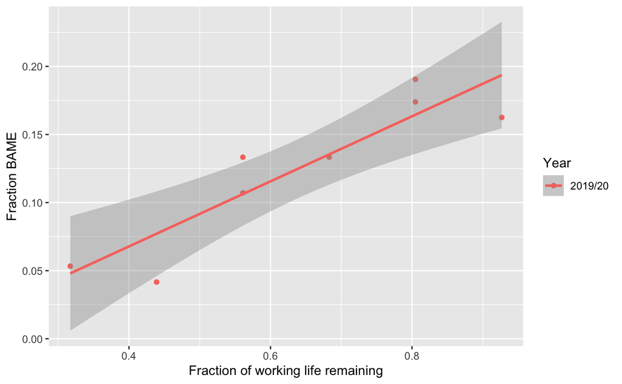

```r
o %>%
  filter(name %in% c("BAME frac"), Year == "2019/20") %>%
  inner_join(., ages) %>%
  ggplot(., aes(x=frac_affected, y=value)) +
    geom_point(aes(colour=Year)) +
    geom_smooth(aes(colour=Year), method="lm") +
    labs(x="Fraction of working life remaining", y="Fraction BAME")
```

What fraction of pension is accrued by age? Choose the youngest possible age, calculate the cumulative percentage of the final pot for each year

```r
annuity <- annuity_rates("women", "joint", years_left("1996/05/01"), 0.005)
income <- income_projection(32000, 0.02, increases_per_year=1, years_left("1996/05/01"), upper_limit=1000000)
pension <- pension_calculation_2020(income, annuity, "Scenario 1", incr="incr_2.5")
```

```r
ages <- pension$uuk1 %>%
  mutate(
    cumperc = total_pot / max(total_pot),
    age=years-1996) %>%
  select(age, cumperc) %>%
  inner_join(ages, .)
```

```r
ages <- ages %>%
    group_by(position) %>%
    do({
        x <- .
        annuity <- annuity_rates("men", "joint", x$to_retirement)
        income <- income_projection(x$salary, 0.02, increases_per_year=1, x$to_retirement, upper_limit=1000000)
        pension <- pension_calculation_2020(income, annuity, "Scenario 1", incr="incr_2.5") %>% pension_calculation_2020_summary()
        x$current <- subset(pension, scenario == "current")$total_pot
        x$uuk1 <- subset(pension, scenario == "uuk1")$total_pot
        x$future_reduction <- 1 - x$uuk1 / x$current
        x$total_reduction <- x$frac_affected * x$reduction
        x
    })
```

```
|==================================================================|100% ~0 s remaining
```

If the future accrual is reduced by ~1/3, for each member of staff ask what fraction of their total accrual is reduced by ~1/3, i.e. what fraction of total accrual is reduced by 1/3

```r
summary_bame <- o %>% filter(name %in% c("BAME", "White"), Year == "2019/20") %>%
    inner_join(., ages, by="position") %>%
    group_by(name, Year) %>%
    summarise(mean_reduction=sum(total_reduction * value) / sum(value))
summary_bame
```

| name | Year | mean_reduction |
| --- | --- | --- |
| BAME | 2019/20 | 0.2805760 |
| White | 2019/20 | 0.2509875 |

How much is pension pot reducing for BAME colleagues compared to white colleagues

```r
1 - subset(summary_bame, name=="White")$mean_reduction / subset(summary_bame, name=="BAME")$mean_reduction
```

```
[1] 0.1054563
```

How much is pension pot reducing by grade

```r
summary_grade <- o %>% filter(name %in% c("BAME", "White"), Year == "2019/20") %>%
    inner_join(., ages, by="position") %>%
    group_by(position, Year) %>%
    summarise(mean_reduction=sum(total_reduction * value) / sum(value)) %>%
  arrange(mean_reduction)
summary_grade
```

| position | Year | mean_reduction |
| --- | --- | --- |
| Professor | 2019/20 | 0.0827320 |
| Associate Professor | 2019/20 | 0.1436843 |
| Senior Lecturer | 2019/20 | 0.1929352 |
| Senior Research Fellow | 2019/20 | 0.1929352 |
| Research Fellow | 2019/20 | 0.2591677 |
| Lecturer | 2019/20 | 0.3085868 |
| Senior Research Associate | 2019/20 | 0.3095467 |
| Research Associate | 2019/20 | 0.3571959 |

```r
subset(summary_grade, position=="Research Associate")$mean_reduction/subset(summary_grade, position=="Professor")$mean_reduction
```

```
[1] 4.317506
```